# ESTADISTICAS EN Rstudio

```
## [1] "Rango de Edad"
```

```
## [1] 3
```

```
## [1] "Resumen y Subconjuntos"
```

```
##         estado         sexo           edad        porcentajegrasa
##  MEXICO    : 802   Hombre:1869   Min.   : 7.000   Min.   : 7.00
##  PUEBLA    : 474   Mujer :1868   1st Qu.: 8.000   1st Qu.:16.00
##  NUEVO LEON: 329                 Median : 9.000   Median :20.00
##  VERACRUZ  : 326                 Mean   : 8.734   Mean   :20.88
##  MORELOS   : 314                 3rd Qu.:10.000   3rd Qu.:25.00
##  ZACATECAS : 252                 Max.   :10.000   Max.   :45.00
##  (Other)   :1240
##     cintura          estatura          peso             imc
##  Min.   :  0.00   Min.   :0.160   Min.   : 15.00   Min.   :  6.49
##  1st Qu.: 56.00   1st Qu.:1.270   1st Qu.: 26.00   1st Qu.: 15.50
##  Median : 61.00   Median :1.320   Median : 30.00   Median : 16.96
##  Mean   : 61.38   Mean   :1.324   Mean   : 31.28   Mean   : 17.88
##  3rd Qu.: 68.00   3rd Qu.:1.390   3rd Qu.: 35.90   3rd Qu.: 19.22
##  Max.   :161.00   Max.   :1.640   Max.   :100.00   Max.   :859.38
##
```

```
##        AGUASCALIENTES BAJA CALIFORNIA NORTE   BAJA CALIFORNIA SUR
##                    28                    32                    57
##              CAMPECHE               CHIAPAS             CHIHUAHUA
##                     3                    51                    47
##      CIUDAD DE MEXICO  COAHUILA DE ZARAGOZA                COLIMA
##                    52                    14                    28
##               DURANGO            GUANAJUATO              GUERRERO
##                   117                    87                     7
##               HIDALGO               JALISCO                MEXICO
##                    11                    15                   802
##   MICHOACAN DE OCAMPO               MORELOS               NAYARIT
##                    14                   314                    52
##            NUEVO LEON                OAXACA                PUEBLA
##                   329                     6                   474
##             QUERETARO          QUINTANA ROO       SAN LUIS POTOSI
##                    64                   100                    37
##               SINALOA                SONORA               TABASCO
##                    55                   226                    26
##            TAMAULIPAS              TLAXCALA              VERACRUZ
##                    47                    17                   326
##               YUCATAN             ZACATECAS
##                    47                   252
```

```
##         estado        sexo           edad        porcentajegrasa
##  MEXICO    :802   Hombre:1421   Min.   : 7.000   Min.   : 7.00
##  PUEBLA    :474   Mujer :1419   1st Qu.: 8.000   1st Qu.:16.00
##  NUEVO LEON:329                 Median : 9.000   Median :20.00
##  VERACRUZ  :326                 Mean   : 8.726   Mean   :20.69
##  MORELOS   :314                 3rd Qu.:10.000   3rd Qu.:25.00
##  ZACATECAS :252                 Max.   :10.000   Max.   :45.00
##  (Other)   :343
##     cintura          estatura          peso            imc
##  Min.   :  0.00   Min.   :0.160   Min.   :15.00   Min.   :  8.48
##  1st Qu.: 56.00   1st Qu.:1.260   1st Qu.:25.00   1st Qu.: 15.45
##  Median : 61.00   Median :1.320   Median :30.00   Median : 16.84
##  Mean   : 61.74   Mean   :1.323   Mean   :30.94   Mean   : 17.80
##  3rd Qu.: 68.00   3rd Qu.:1.390   3rd Qu.:35.28   3rd Qu.: 19.02
##  Max.   :100.00   Max.   :1.600   Max.   :75.00   Max.   :859.38
##
```

```
## [1] "Estados con más datos registrados"
```

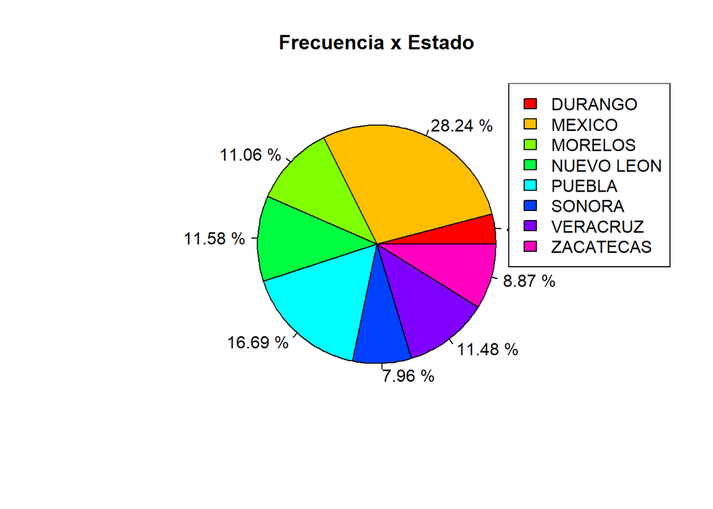

```
## [1] "Registros de poblacion por sexo en cada estado"
```

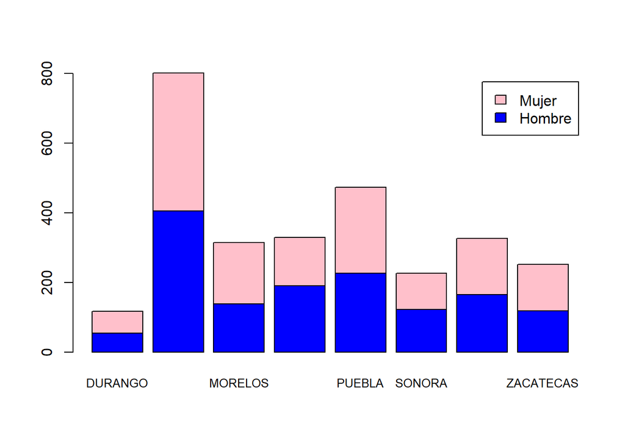

```
##             edad
## estado         7   8   9  10
##   DURANGO     28  20  37  32
##   MEXICO     162 163 235 242
##   MORELOS     77 102  67  68
##   NUEVO LEON  63  58 105 103
##   PUEBLA     106 164  98 106
##   SONORA       2  52  95  77
##   VERACRUZ    21  25 103 177
##   ZACATECAS   47  60  71  74
```

```
##             sexo
## estado       Hombre Mujer
##   DURANGO        54    63
##   MEXICO        405   397
##   MORELOS       139   175
##   NUEVO LEON    190   139
##   PUEBLA        227   247
##   SONORA        122   104
##   VERACRUZ      165   161
##   ZACATECAS     119   133
```

```
##   edades Durango Mexico Morelos NuevoLeon Puebla Sonora Veracruz Zacatecas
## 1      7    24 %   20 %    25 %      19 %   22 %    1 %      6 %      19 %
## 2      8    17 %   20 %    32 %      18 %   35 %   23 %      8 %      24 %
## 3      9    32 %   29 %    21 %      32 %   21 %   42 %     32 %      28 %
## 4     10    27 %   30 %    22 %      31 %   22 %   34 %     54 %      29 %
```

```
##    sexos Durango Mexico Morelos NuevoLeon Puebla Sonora Veracruz Zacatecas
## 1 Hombre    46 %   50 %    44 %      58 %   48 %   54 %     51 %      47 %
## 2  Mujer    54 %   50 %    56 %      42 %   52 %   46 %     49 %      53 %
```

Si analizamos la grafica de frecuencia podemos deducir que la región con más datos obtenidos es el centro de la republica mexicana (Mexico, Puebla, Morelos).

Tambien podemos deducir por el analisis de la grafica y la tabla porcentual de sexo por estados que no hay una variación de más del 10% a partir del 50% entre cada sexo.

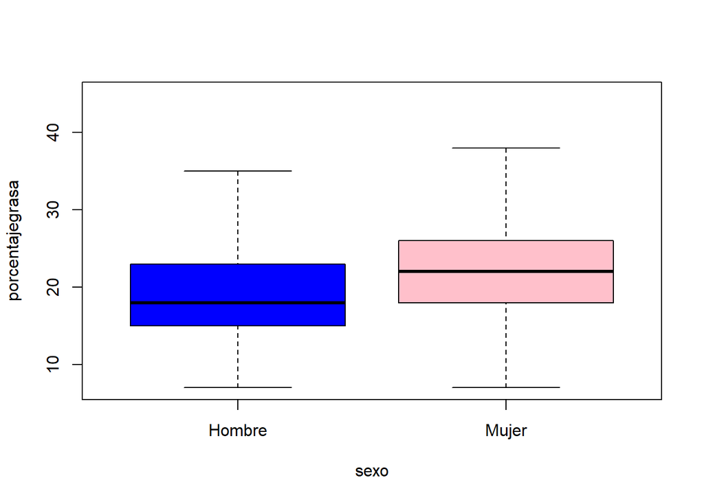

Graficamente observamos que el porcentaje de grasa en hombres es menor que en mujeres. Se puede argumentar que un estudio explica que la razón principal por la cual las muejeres acumulan mayor porcentaje de grasa que los hombres es debido a la fecundidad, desarrollo fetal y la lactancia.

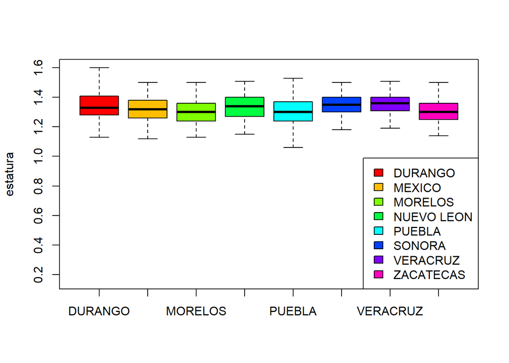

```
## [1] "DECILES"
```

```
##  10%  20%  30%  40%  50%  60%  70%  80%  90% 100%
##   52   55   57   59   61   63   66   70   75  100
```

```
## [1] "PERCENTIL 20, 40, 60, 80"
```

```
##   0%  20%  40%  60%  80% 100%
##    0   55   59   63   70  100
```

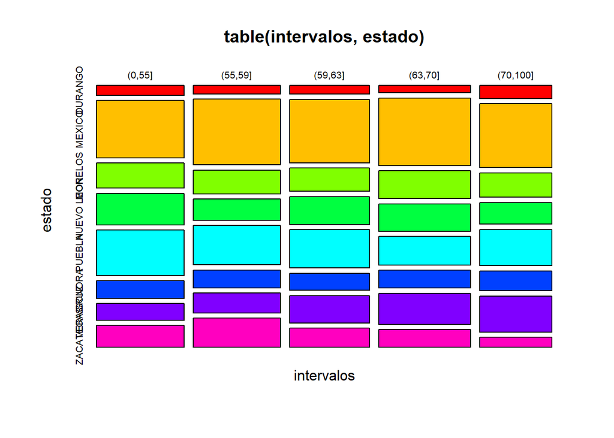

Estadisticamente podemos observar que el top 3 estados con mayor indice de masa corporal (a partir de 26 imc), son:

TOP 1: PUEBLA(48 datos); TOP 2: VERACRUZ(28 datos); TOP 3: DURANGO (15 datos)

```
## [1] "HISTOGRAMA ESTATURA"
```

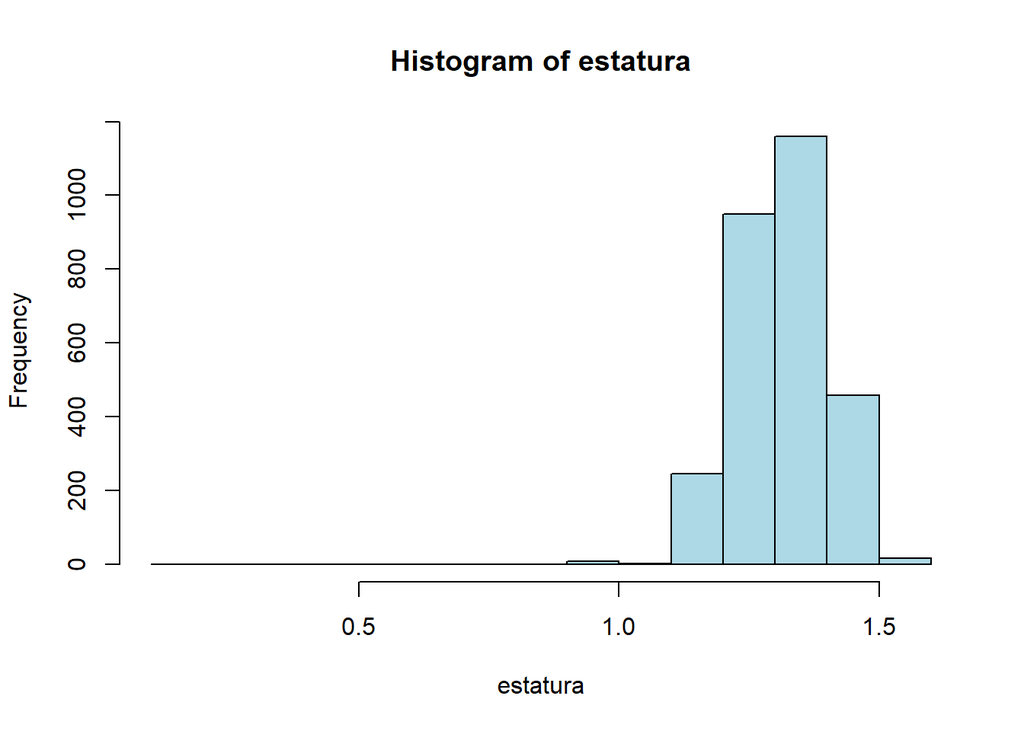

```
## [1] "Media"
```

```
## [1] 1.322595
```

```
## [1] "Mediana"
```

```
## [1] 1.32
```

```
## [1] "Podemos observar que la media es mayor que la mediana, por lo tanto se deduce que es asimetrica hacia la izquierda y decimos que el sesgo es hacia la derecha"
```

```
## [1] "HISTOGRAMA PESO"
```

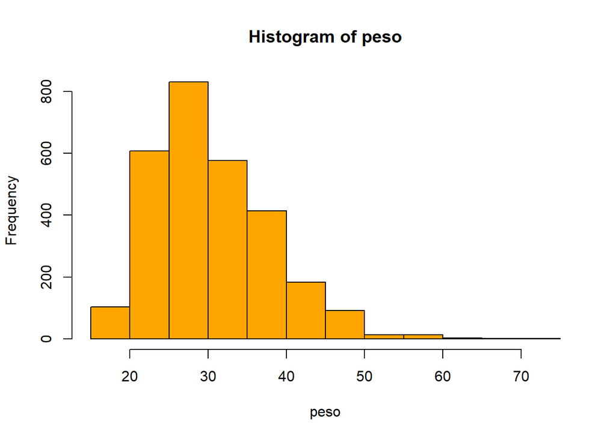

```
## [1] "HISTOGRAMA PESO (Intervalos pequeños"
```

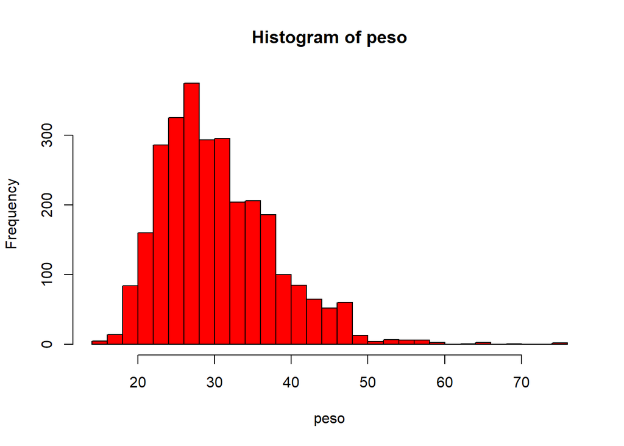

```
## [1] "Media, Mediana y Moda de PESO"
```

```
## [1] 30.93849
```

```
## [1] 30
```

```
## [1] 28
## attr(,"freq")
## [1] 190
```

```
## [1] "OJIVA"
```

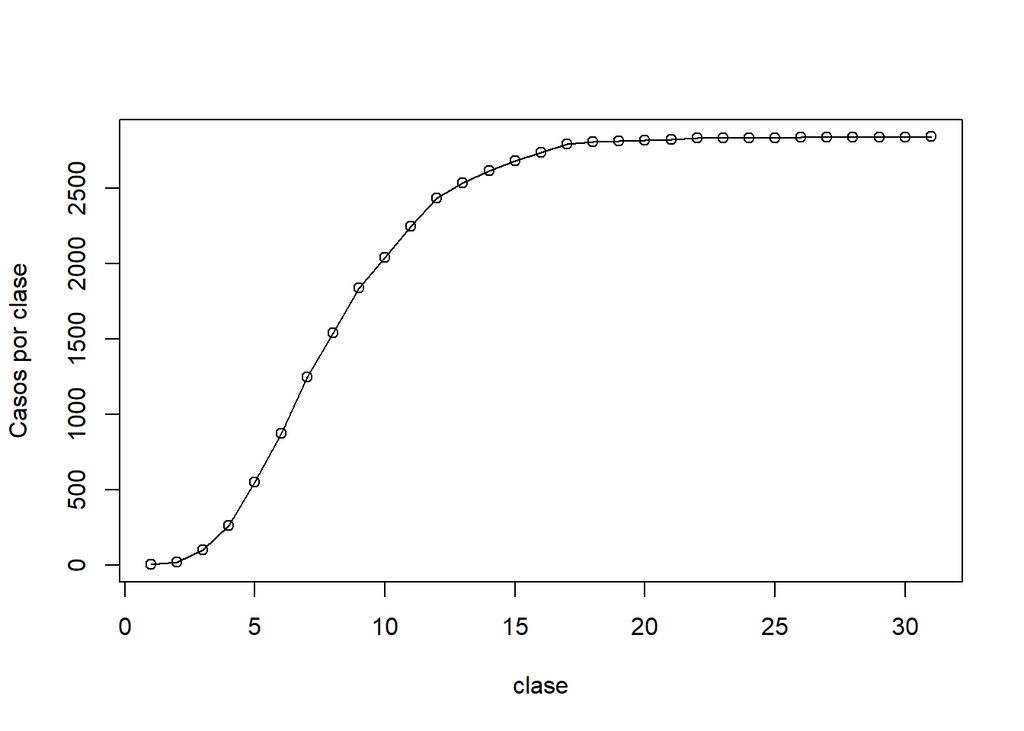

```
## [1] "CINTURA vs EDAD"
```

```
##        edad
## cintura  7  8  9 10
##     0    0  1  0  0
##     20   7  7 11 16
##     21   0  0  1  1
##     22   0  2  0  0
##     23   0  0  1  2
##     24   0  0  0  1
##     25   1  0  0  3
##     27   0  0  0  1
##     28   1  0  0  1
##     29   0  0  1  0
##     30   1  0  0  1
##     31   0  3  0  0
##     32   1  0  1  1
```

[output cut: 63 more lines]

```
## [1] "PROMEDIO"
```

```
## [1] 9.342105
```

```
## [1] "DESVIACION ESTANDAR"
```

```
## [1] 13.11141
```

```
## [1] "COEFICIENTE DE VARIACION"
```

```
## [1] 140.3474
```

```
## [1] "PESO vs EDAD"
```

```
##        edad
## peso     7  8  9 10
##   15     3  1  1  0
##   17     2  1  0  0
##   18     9  1  1  0
##   19    17  3  1  0
##   20    42 20  1  0
##   21    58 16  3  0
##   22    47 24 12  0
##   23    49 41 26  0
##   23.84  5  0  0  0
##   23.9   7  0  0  0
##   23.91  1  0  0  0
##   23.93  4  0  0  0
##   24    46 70 34  3
##   24.23  3  0  0  0
##   24.43  2  0  0  0
##   24.51  6  0  0  0
##   24.6   1  0  0  0
##   24.95  4  0  0  0
##   25    40 52 36 18
##   26    36 51 45 31
##   27    22 46 68 31
##   27.32  0  5  0  0
##   27.36  0  2  0  0
##   27.49  0  1  0  0
##   27.55  0  1  0  0
##   27.77  0  2  0  0
##   27.95  0  3  0  0
##   27.97  0  3  0  0
##   28    20 51 66 53
##   28.13  0  4  0  0
##   28.15  0  4  0  0
##   28.59  0  1  0  0
##   28.9   0  2  0  0
##   29    24 33 39 36
##   29.46  0  1  0  0
##   30    18 35 48 48
##   30.94  0  0  6  0
##   31     5 26 38 52
```

[output cut: 39 more lines]

```
##   51     0  1  0  0
##   52     1  1  0  1
##   53     1  1  0  2
##   54     0  1  1  1
##   55     0  0  0  2
##   56     0  1  2  1
##   57     0  0  1  1
##   58     0  1  0  3
##   59     0  0  1  0
##   60     0  0  1  1
##   64     0  0  0  1
##   65     0  1  1  0
##   66     0  0  0  1
##   69     0  1  0  0
##   75     0  0  0  2
```

```
## [1] "PROMEDIO"
```

```
## [1] 7.717391
```

```
## [1] "DESVIACION ESTANDAR"
```

```
## [1] 14.59859
```

```
## [1] "COEFICIENTE DE VARIACION"
```

```
## [1] 189.1648
```

“DIAGRAMAS DE DISPERSION”

```
## [1] "PESO vs EDAD"
```

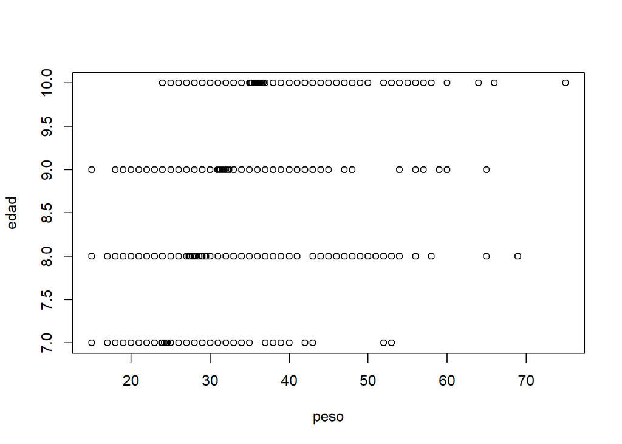

```
## [1] "ESTATURA vs EDAD"
```

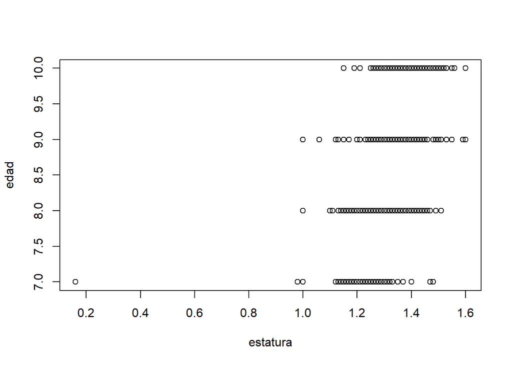

```
## [1] "IMC vs EDAD"
```

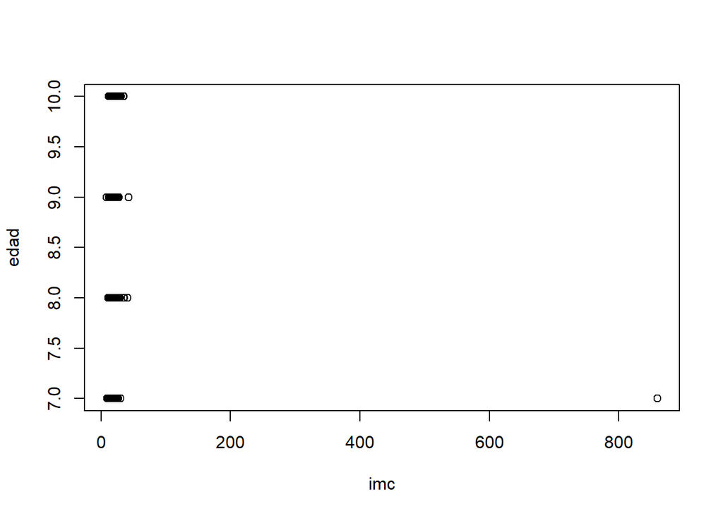

```
## [1] "Edad(8), Sexo(Hombre)"
```

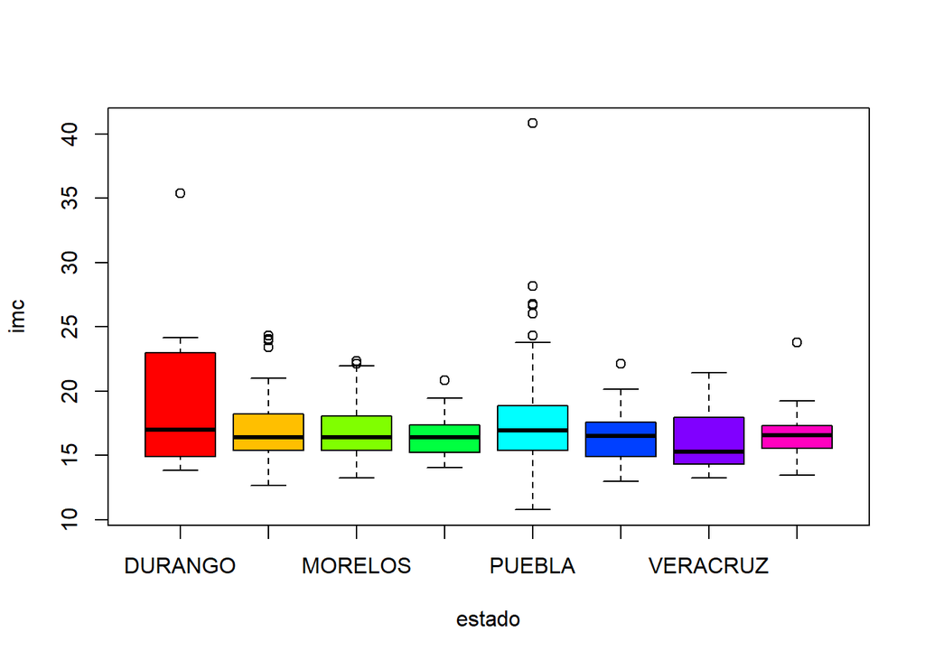

[figure not shown]

```
## [1] "Edad(8), Sexo(Mujer)"
```

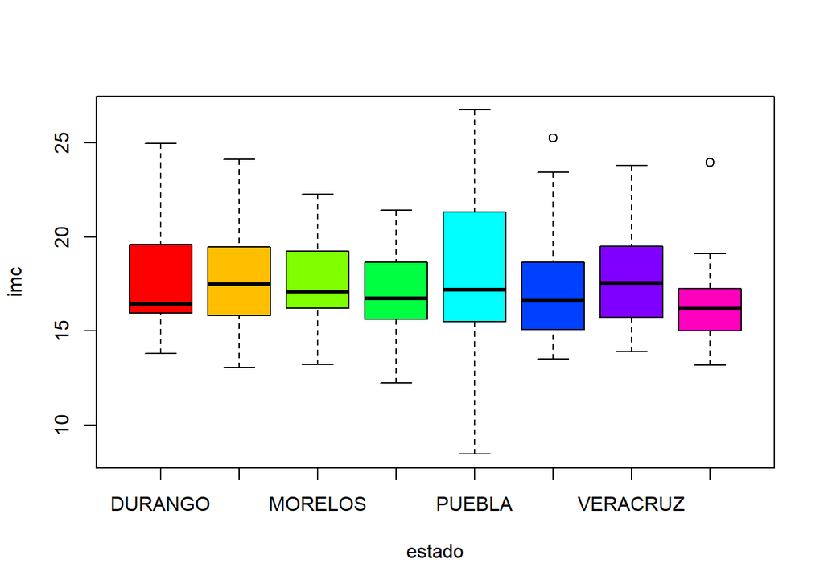

```
## [1] "Edad(9), Sexo(Hombre)"
```

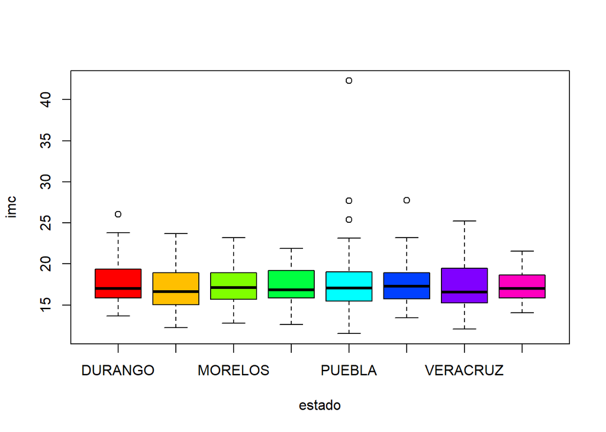

[output not shown]

GRAFICOS ADICIONALES

```
## [1] "Frecuencia por intervalos de cintura"
```

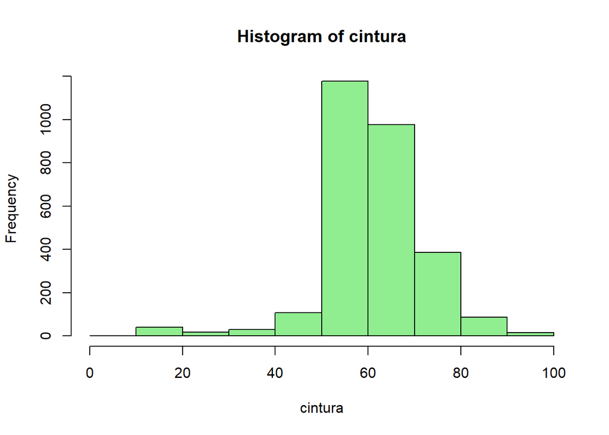

```
## [1] "EDAD vs Indice de Masa Corporal"
```

[output not shown]

[output cut: 245 more lines]

[output not shown]

```
## [1] "Mosaico Edad vs Estado"
```

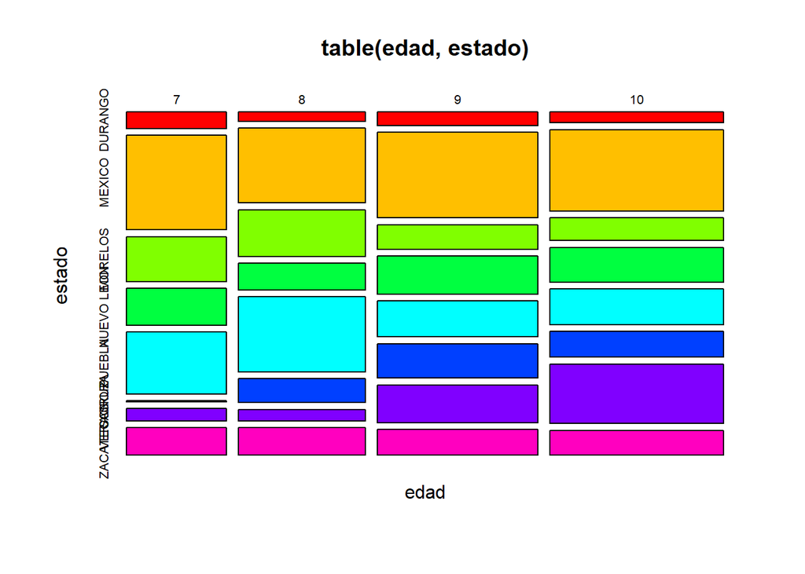